# examples_0403

First, there are 12 voters, so a candidate needs at least 7 votes to win a majority.

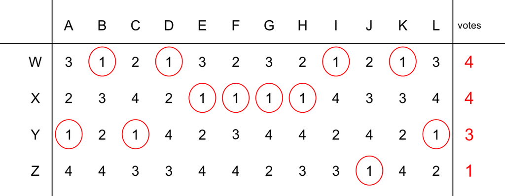

Nobody has a majority. Candidate Z has the fewest votes. Eliminate candidate Z from the contest. Each voter's vote goes to their top candidate still in the election.

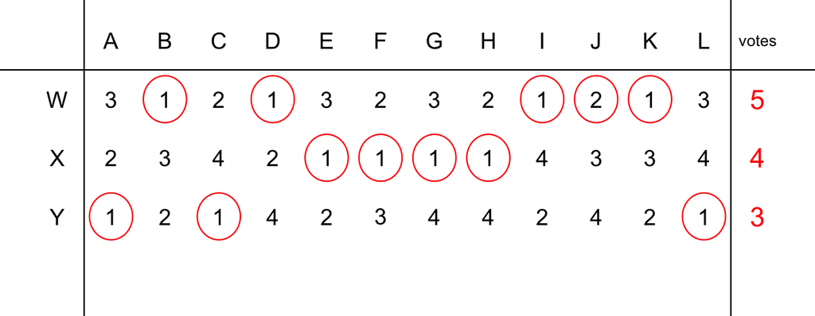

Nobody has a majority. Candidate Y has the fewest votes. Eliminate candidate Y from the contest. Each voter's vote goes to their top candidate still in the election.

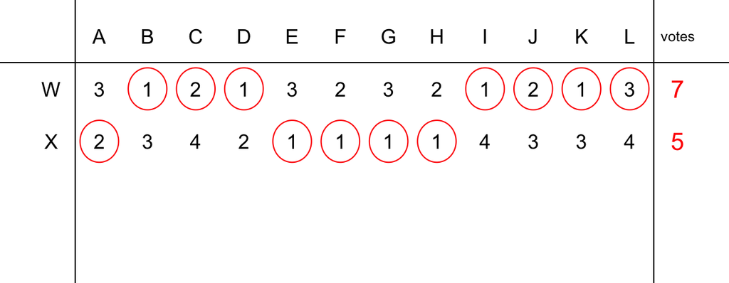

Candidate W has gotten majority vote. Candidate W wins!

In Adams, Massachusetts, 4 candidates (W through Z) are running in an election with a single winner. There are 9 voters (A through I) who each rank the candidates from 1 to 4, with 1 meaning first choice and 4 meaning last choice. Those rankings are shown below. Each column represents a single voter's ranking.

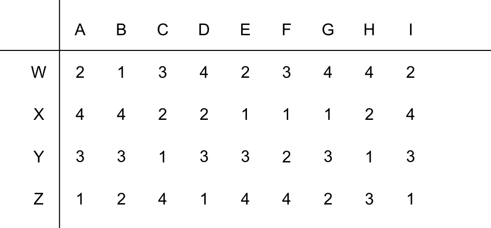

Who would win an [instant-runoff election](https://en.wikipedia.org/wiki/Instant-runoff_voting)?

Candidate WCandidate XCandidate YCandidate Z

First, there are 9 voters, so a candidate needs at least 5 votes to win a majority.

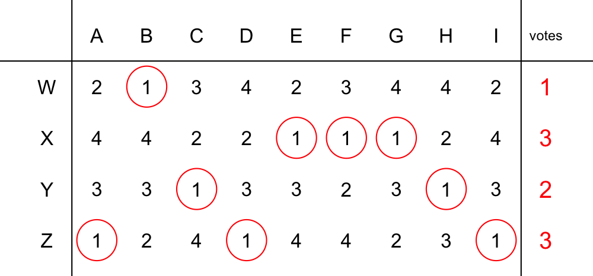

Nobody has a majority. Candidate W has the fewest votes. Eliminate candidate W from the contest. Each voter's vote goes to their top candidate still in the election.

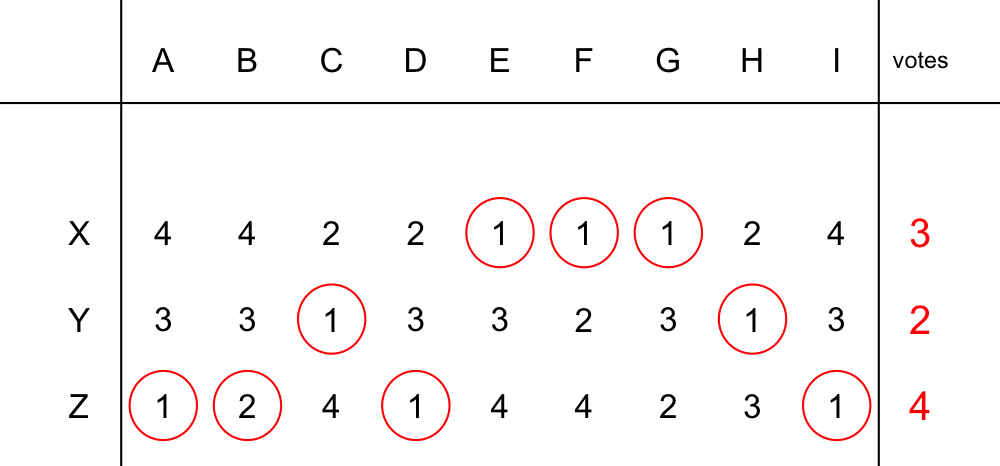

Nobody has a majority. Candidate Y has the fewest votes. Eliminate candidate Y from the contest. Each voter's vote goes to their top candidate still in the election.

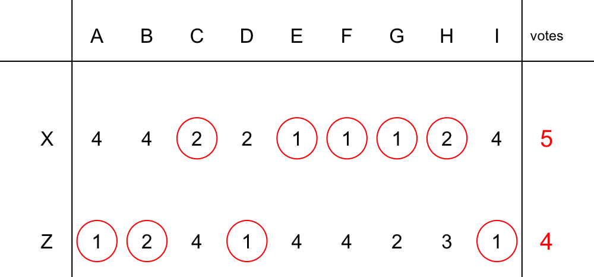

Candidate X has gotten majority vote. Candidate X wins!

In Adams, Massachusetts, 4 candidates (W through Z) are running in an election with a single winner. There are 11 voters (A through K) who each rank the candidates from 1 to 4, with 1 meaning first choice and 4 meaning last choice. Those rankings are shown below. Each column represents a single voter's ranking.

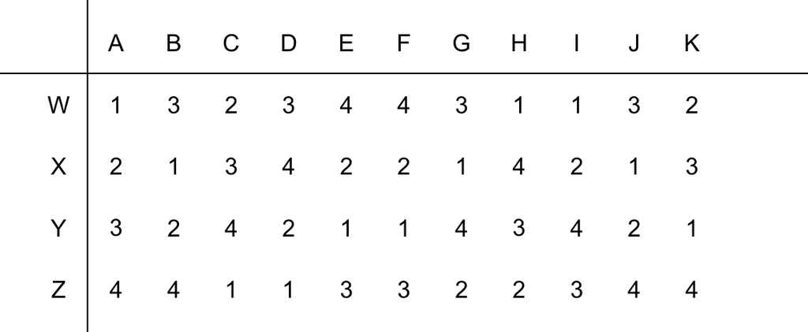

Who would win an [instant-runoff election](https://en.wikipedia.org/wiki/Instant-runoff_voting)?

Candidate WCandidate XCandidate YCandidate Z

First, there are 11 voters, so a candidate needs at least 6 votes to win a majority.

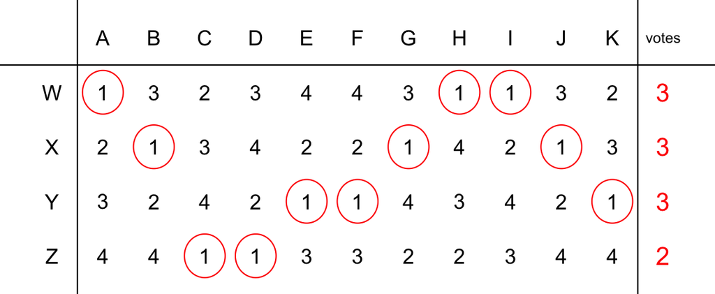

Nobody has a majority. Candidate Z has the fewest votes. Eliminate candidate Z from the contest. Each voter's vote goes to their top candidate still in the election.

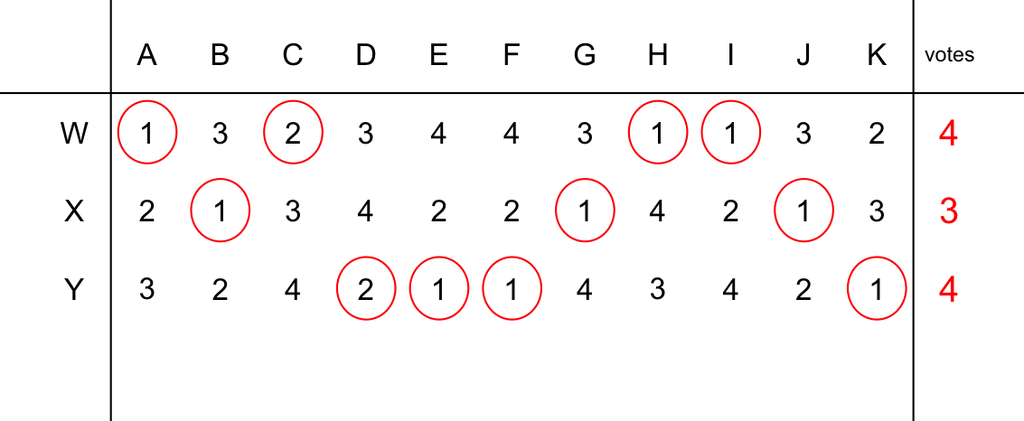

Nobody has a majority. Candidate X has the fewest votes. Eliminate candidate X from the contest. Each voter's vote goes to their top candidate still in the election.

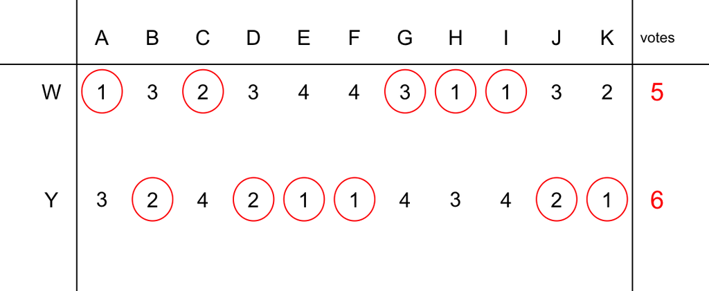

Candidate Y has gotten majority vote. Candidate Y wins!

In Adams, Massachusetts, 4 candidates (W through Z) are running in an election with a single winner. There are 9 voters (A through I) who each rank the candidates from 1 to 4, with 1 meaning first choice and 4 meaning last choice. Those rankings are shown below. Each column represents a single voter's ranking.

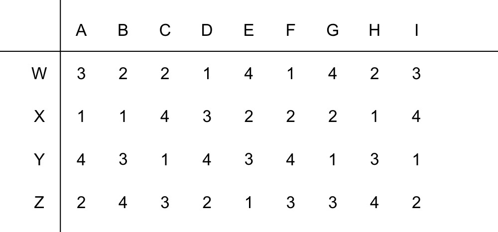

Who would win an [instant-runoff election](https://en.wikipedia.org/wiki/Instant-runoff_voting)?

Candidate WCandidate XCandidate YCandidate Z

First, there are 9 voters, so a candidate needs at least 5 votes to win a majority.

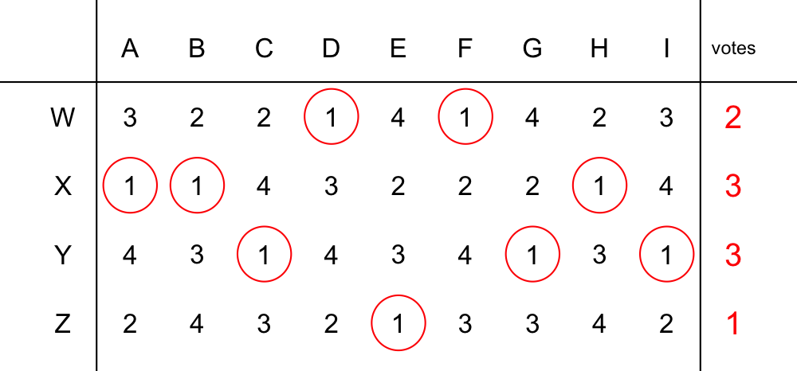

Nobody has a majority. Candidate Z has the fewest votes. Eliminate candidate Z from the contest. Each voter's vote goes to their top candidate still in the election.

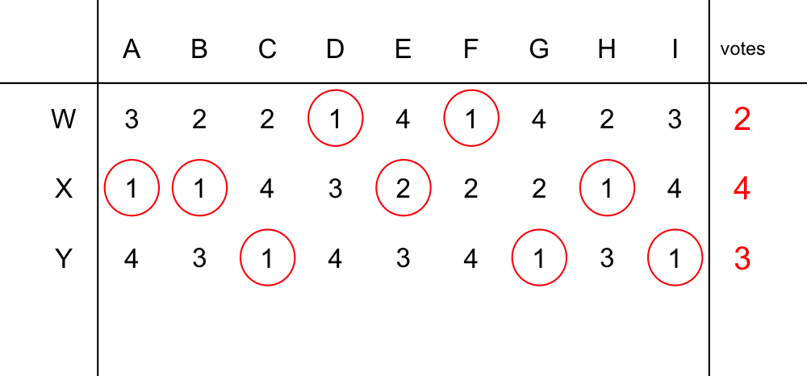

Nobody has a majority. Candidate W has the fewest votes. Eliminate candidate W from the contest. Each voter's vote goes to their top candidate still in the election.

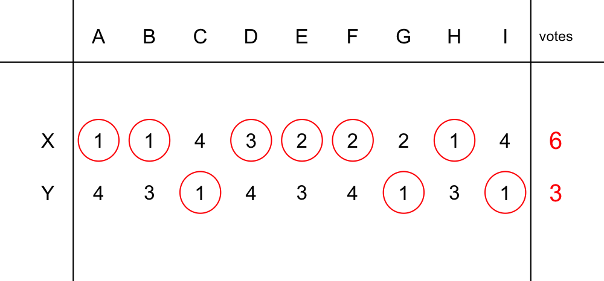

Candidate X has gotten majority vote. Candidate X wins!

In an [approval-vote election](https://en.wikipedia.org/wiki/Approval_voting), there are 4 candidates and 79 voters. Each voter indicated which candidates they approve of (with a 1) or disapprove of (with a 0). All possible ballots are shown below, and the table indicates how many of each type of ballot was cast.

| Number of ballots | 0 | 8 | 8 | 2 | 3 | 2 | 1 | 11 | 4 | 12 | 1 | 4 | 6 | 13 | 4 | 0 |
| --- | --- | --- | --- | --- | --- | --- | --- | --- | --- | --- | --- | --- | --- | --- | --- | --- |
| Candidate W | 1 | 1 | 1 | 1 | 1 | 1 | 1 | 1 | 0 | 0 | 0 | 0 | 0 | 0 | 0 | 0 |
| Candidate X | 1 | 1 | 1 | 1 | 0 | 0 | 0 | 0 | 1 | 1 | 1 | 1 | 0 | 0 | 0 | 0 |
| Candidate Y | 1 | 1 | 0 | 0 | 1 | 1 | 0 | 0 | 1 | 1 | 0 | 0 | 1 | 1 | 0 | 0 |
| Candidate Z | 1 | 0 | 1 | 0 | 1 | 0 | 1 | 0 | 1 | 0 | 1 | 0 | 1 | 0 | 1 | 0 |

1. How many approvals did Candidate W get?
2. How many approvals did Candidate X get?
3. How many approvals did Candidate Y get?
4. How many approvals did Candidate Z get?
5. Who won the election?

Each "1" corresponds to the ballot count number of votes. We can make another table with votes counts.

| Number of ballots | 0 | 8 | 8 | 2 | 3 | 2 | 1 | 11 | 4 | 12 | 1 | 4 | 6 | 13 | 4 | 0 |
| --- | --- | --- | --- | --- | --- | --- | --- | --- | --- | --- | --- | --- | --- | --- | --- | --- |
| Candidate W | 0 | 8 | 8 | 2 | 3 | 2 | 1 | 11 | 0 | 0 | 0 | 0 | 0 | 0 | 0 | 0 |
| Candidate X | 0 | 8 | 8 | 2 | 0 | 0 | 0 | 0 | 4 | 12 | 1 | 4 | 0 | 0 | 0 | 0 |
| Candidate Y | 0 | 8 | 0 | 0 | 3 | 2 | 0 | 0 | 4 | 12 | 0 | 0 | 6 | 13 | 0 | 0 |
| Candidate Z | 0 | 0 | 8 | 0 | 3 | 0 | 1 | 0 | 4 | 0 | 1 | 0 | 6 | 0 | 4 | 0 |

And then just sum each row.

- Candidate W got 35 approvals
- Candidate X got 39 approvals
- Candidate Y got 48 approvals
- Candidate Z got 27 approvals

And we see that Candidate Y is the winner.

In an [approval-vote election](https://en.wikipedia.org/wiki/Approval_voting), there are 4 candidates and 163 voters. Each voter indicated which candidates they approve of (with a 1) or disapprove of (with a 0). All possible ballots are shown below, and the table indicates how many of each type of ballot was cast.

| Number of ballots | 0 | 38 | 7 | 5 | 4 | 16 | 3 | 22 | 15 | 17 | 2 | 7 | 3 | 5 | 19 | 0 |
| --- | --- | --- | --- | --- | --- | --- | --- | --- | --- | --- | --- | --- | --- | --- | --- | --- |
| Candidate W | 1 | 1 | 1 | 1 | 1 | 1 | 1 | 1 | 0 | 0 | 0 | 0 | 0 | 0 | 0 | 0 |
| Candidate X | 1 | 1 | 1 | 1 | 0 | 0 | 0 | 0 | 1 | 1 | 1 | 1 | 0 | 0 | 0 | 0 |
| Candidate Y | 1 | 1 | 0 | 0 | 1 | 1 | 0 | 0 | 1 | 1 | 0 | 0 | 1 | 1 | 0 | 0 |
| Candidate Z | 1 | 0 | 1 | 0 | 1 | 0 | 1 | 0 | 1 | 0 | 1 | 0 | 1 | 0 | 1 | 0 |

1. How many approvals did Candidate W get?
2. How many approvals did Candidate X get?
3. How many approvals did Candidate Y get?
4. How many approvals did Candidate Z get?
5. Who won the election?

Each "1" corresponds to the ballot count number of votes. We can make another table with votes counts.

| Number of ballots | 0 | 38 | 7 | 5 | 4 | 16 | 3 | 22 | 15 | 17 | 2 | 7 | 3 | 5 | 19 | 0 |
| --- | --- | --- | --- | --- | --- | --- | --- | --- | --- | --- | --- | --- | --- | --- | --- | --- |
| Candidate W | 0 | 38 | 7 | 5 | 4 | 16 | 3 | 22 | 0 | 0 | 0 | 0 | 0 | 0 | 0 | 0 |
| Candidate X | 0 | 38 | 7 | 5 | 0 | 0 | 0 | 0 | 15 | 17 | 2 | 7 | 0 | 0 | 0 | 0 |
| Candidate Y | 0 | 38 | 0 | 0 | 4 | 16 | 0 | 0 | 15 | 17 | 0 | 0 | 3 | 5 | 0 | 0 |
| Candidate Z | 0 | 0 | 7 | 0 | 4 | 0 | 3 | 0 | 15 | 0 | 2 | 0 | 3 | 0 | 19 | 0 |

And then just sum each row.

- Candidate W got 95 approvals
- Candidate X got 91 approvals
- Candidate Y got 98 approvals
- Candidate Z got 53 approvals

And we see that Candidate Y is the winner.

In an [approval-vote election](https://en.wikipedia.org/wiki/Approval_voting), there are 4 candidates and 56 voters. Each voter indicated which candidates they approve of (with a 1) or disapprove of (with a 0). All possible ballots are shown below, and the table indicates how many of each type of ballot was cast.

| Number of ballots | 0 | 2 | 10 | 7 | 10 | 1 | 3 | 1 | 3 | 1 | 1 | 3 | 1 | 10 | 3 | 0 |
| --- | --- | --- | --- | --- | --- | --- | --- | --- | --- | --- | --- | --- | --- | --- | --- | --- |
| Candidate W | 1 | 1 | 1 | 1 | 1 | 1 | 1 | 1 | 0 | 0 | 0 | 0 | 0 | 0 | 0 | 0 |
| Candidate X | 1 | 1 | 1 | 1 | 0 | 0 | 0 | 0 | 1 | 1 | 1 | 1 | 0 | 0 | 0 | 0 |
| Candidate Y | 1 | 1 | 0 | 0 | 1 | 1 | 0 | 0 | 1 | 1 | 0 | 0 | 1 | 1 | 0 | 0 |
| Candidate Z | 1 | 0 | 1 | 0 | 1 | 0 | 1 | 0 | 1 | 0 | 1 | 0 | 1 | 0 | 1 | 0 |

1. How many approvals did Candidate W get?
2. How many approvals did Candidate X get?
3. How many approvals did Candidate Y get?
4. How many approvals did Candidate Z get?
5. Who won the election?

Each "1" corresponds to the ballot count number of votes. We can make another table with votes counts.

| Number of ballots | 0 | 2 | 10 | 7 | 10 | 1 | 3 | 1 | 3 | 1 | 1 | 3 | 1 | 10 | 3 | 0 |
| --- | --- | --- | --- | --- | --- | --- | --- | --- | --- | --- | --- | --- | --- | --- | --- | --- |
| Candidate W | 0 | 2 | 10 | 7 | 10 | 1 | 3 | 1 | 0 | 0 | 0 | 0 | 0 | 0 | 0 | 0 |
| Candidate X | 0 | 2 | 10 | 7 | 0 | 0 | 0 | 0 | 3 | 1 | 1 | 3 | 0 | 0 | 0 | 0 |
| Candidate Y | 0 | 2 | 0 | 0 | 10 | 1 | 0 | 0 | 3 | 1 | 0 | 0 | 1 | 10 | 0 | 0 |
| Candidate Z | 0 | 0 | 10 | 0 | 10 | 0 | 3 | 0 | 3 | 0 | 1 | 0 | 1 | 0 | 3 | 0 |

And then just sum each row.

- Candidate W got 34 approvals
- Candidate X got 27 approvals
- Candidate Y got 28 approvals
- Candidate Z got 31 approvals

And we see that Candidate W is the winner.

In an [approval-vote election](https://en.wikipedia.org/wiki/Approval_voting), there are 4 candidates and 159 voters. Each voter indicated which candidates they approve of (with a 1) or disapprove of (with a 0). All possible ballots are shown below, and the table indicates how many of each type of ballot was cast.

| Number of ballots | 0 | 10 | 8 | 24 | 1 | 36 | 14 | 18 | 6 | 15 | 7 | 4 | 8 | 3 | 5 | 0 |
| --- | --- | --- | --- | --- | --- | --- | --- | --- | --- | --- | --- | --- | --- | --- | --- | --- |
| Candidate W | 1 | 1 | 1 | 1 | 1 | 1 | 1 | 1 | 0 | 0 | 0 | 0 | 0 | 0 | 0 | 0 |
| Candidate X | 1 | 1 | 1 | 1 | 0 | 0 | 0 | 0 | 1 | 1 | 1 | 1 | 0 | 0 | 0 | 0 |
| Candidate Y | 1 | 1 | 0 | 0 | 1 | 1 | 0 | 0 | 1 | 1 | 0 | 0 | 1 | 1 | 0 | 0 |
| Candidate Z | 1 | 0 | 1 | 0 | 1 | 0 | 1 | 0 | 1 | 0 | 1 | 0 | 1 | 0 | 1 | 0 |

1. How many approvals did Candidate W get?
2. How many approvals did Candidate X get?
3. How many approvals did Candidate Y get?
4. How many approvals did Candidate Z get?
5. Who won the election?

Each "1" corresponds to the ballot count number of votes. We can make another table with votes counts.

| Number of ballots | 0 | 10 | 8 | 24 | 1 | 36 | 14 | 18 | 6 | 15 | 7 | 4 | 8 | 3 | 5 | 0 |
| --- | --- | --- | --- | --- | --- | --- | --- | --- | --- | --- | --- | --- | --- | --- | --- | --- |
| Candidate W | 0 | 10 | 8 | 24 | 1 | 36 | 14 | 18 | 0 | 0 | 0 | 0 | 0 | 0 | 0 | 0 |
| Candidate X | 0 | 10 | 8 | 24 | 0 | 0 | 0 | 0 | 6 | 15 | 7 | 4 | 0 | 0 | 0 | 0 |
| Candidate Y | 0 | 10 | 0 | 0 | 1 | 36 | 0 | 0 | 6 | 15 | 0 | 0 | 8 | 3 | 0 | 0 |
| Candidate Z | 0 | 0 | 8 | 0 | 1 | 0 | 14 | 0 | 6 | 0 | 7 | 0 | 8 | 0 | 5 | 0 |

And then just sum each row.

- Candidate W got 111 approvals
- Candidate X got 74 approvals
- Candidate Y got 79 approvals
- Candidate Z got 49 approvals

And we see that Candidate W is the winner.

In an [approval-vote election](https://en.wikipedia.org/wiki/Approval_voting), there are 4 candidates and 91 voters. Each voter indicated which candidates they approve of (with a 1) or disapprove of (with a 0). All possible ballots are shown below, and the table indicates how many of each type of ballot was cast.

| Number of ballots | 0 | 14 | 1 | 7 | 12 | 2 | 11 | 2 | 5 | 3 | 2 | 10 | 6 | 2 | 14 | 0 |
| --- | --- | --- | --- | --- | --- | --- | --- | --- | --- | --- | --- | --- | --- | --- | --- | --- |
| Candidate W | 1 | 1 | 1 | 1 | 1 | 1 | 1 | 1 | 0 | 0 | 0 | 0 | 0 | 0 | 0 | 0 |
| Candidate X | 1 | 1 | 1 | 1 | 0 | 0 | 0 | 0 | 1 | 1 | 1 | 1 | 0 | 0 | 0 | 0 |
| Candidate Y | 1 | 1 | 0 | 0 | 1 | 1 | 0 | 0 | 1 | 1 | 0 | 0 | 1 | 1 | 0 | 0 |
| Candidate Z | 1 | 0 | 1 | 0 | 1 | 0 | 1 | 0 | 1 | 0 | 1 | 0 | 1 | 0 | 1 | 0 |

1. How many approvals did Candidate W get?
2. How many approvals did Candidate X get?
3. How many approvals did Candidate Y get?
4. How many approvals did Candidate Z get?
5. Who won the election?

Each "1" corresponds to the ballot count number of votes. We can make another table with votes counts.

| Number of ballots | 0 | 14 | 1 | 7 | 12 | 2 | 11 | 2 | 5 | 3 | 2 | 10 | 6 | 2 | 14 | 0 |
| --- | --- | --- | --- | --- | --- | --- | --- | --- | --- | --- | --- | --- | --- | --- | --- | --- |
| Candidate W | 0 | 14 | 1 | 7 | 12 | 2 | 11 | 2 | 0 | 0 | 0 | 0 | 0 | 0 | 0 | 0 |
| Candidate X | 0 | 14 | 1 | 7 | 0 | 0 | 0 | 0 | 5 | 3 | 2 | 10 | 0 | 0 | 0 | 0 |
| Candidate Y | 0 | 14 | 0 | 0 | 12 | 2 | 0 | 0 | 5 | 3 | 0 | 0 | 6 | 2 | 0 | 0 |
| Candidate Z | 0 | 0 | 1 | 0 | 12 | 0 | 11 | 0 | 5 | 0 | 2 | 0 | 6 | 0 | 14 | 0 |

And then just sum each row.

- Candidate W got 49 approvals
- Candidate X got 42 approvals
- Candidate Y got 44 approvals
- Candidate Z got 51 approvals

And we see that Candidate Z is the winner.

In an [approval-vote election](https://en.wikipedia.org/wiki/Approval_voting), there are 4 candidates and 192 voters. Each voter indicated which candidates they approve of (with a 1) or disapprove of (with a 0). All possible ballots are shown below, and the table indicates how many of each type of ballot was cast.

| Number of ballots | 0 | 2 | 2 | 17 | 7 | 15 | 4 | 23 | 33 | 2 | 1 | 22 | 53 | 2 | 9 | 0 |
| --- | --- | --- | --- | --- | --- | --- | --- | --- | --- | --- | --- | --- | --- | --- | --- | --- |
| Candidate W | 1 | 1 | 1 | 1 | 1 | 1 | 1 | 1 | 0 | 0 | 0 | 0 | 0 | 0 | 0 | 0 |
| Candidate X | 1 | 1 | 1 | 1 | 0 | 0 | 0 | 0 | 1 | 1 | 1 | 1 | 0 | 0 | 0 | 0 |
| Candidate Y | 1 | 1 | 0 | 0 | 1 | 1 | 0 | 0 | 1 | 1 | 0 | 0 | 1 | 1 | 0 | 0 |
| Candidate Z | 1 | 0 | 1 | 0 | 1 | 0 | 1 | 0 | 1 | 0 | 1 | 0 | 1 | 0 | 1 | 0 |

1. How many approvals did Candidate W get?
2. How many approvals did Candidate X get?
3. How many approvals did Candidate Y get?
4. How many approvals did Candidate Z get?
5. Who won the election?

Each "1" corresponds to the ballot count number of votes. We can make another table with votes counts.

| Number of ballots | 0 | 2 | 2 | 17 | 7 | 15 | 4 | 23 | 33 | 2 | 1 | 22 | 53 | 2 | 9 | 0 |
| --- | --- | --- | --- | --- | --- | --- | --- | --- | --- | --- | --- | --- | --- | --- | --- | --- |
| Candidate W | 0 | 2 | 2 | 17 | 7 | 15 | 4 | 23 | 0 | 0 | 0 | 0 | 0 | 0 | 0 | 0 |
| Candidate X | 0 | 2 | 2 | 17 | 0 | 0 | 0 | 0 | 33 | 2 | 1 | 22 | 0 | 0 | 0 | 0 |
| Candidate Y | 0 | 2 | 0 | 0 | 7 | 15 | 0 | 0 | 33 | 2 | 0 | 0 | 53 | 2 | 0 | 0 |
| Candidate Z | 0 | 0 | 2 | 0 | 7 | 0 | 4 | 0 | 33 | 0 | 1 | 0 | 53 | 0 | 9 | 0 |

And then just sum each row.

- Candidate W got 70 approvals
- Candidate X got 79 approvals
- Candidate Y got 114 approvals
- Candidate Z got 109 approvals

And we see that Candidate Y is the winner.

In an [approval-vote election](https://en.wikipedia.org/wiki/Approval_voting), there are 4 candidates and 200 voters. Each voter indicated which candidates they approve of (with a 1) or disapprove of (with a 0). All possible ballots are shown below, and the table indicates how many of each type of ballot was cast.

| Number of ballots | 0 | 3 | 39 | 3 | 2 | 32 | 1 | 47 | 5 | 14 | 6 | 7 | 23 | 13 | 5 | 0 |
| --- | --- | --- | --- | --- | --- | --- | --- | --- | --- | --- | --- | --- | --- | --- | --- | --- |
| Candidate W | 1 | 1 | 1 | 1 | 1 | 1 | 1 | 1 | 0 | 0 | 0 | 0 | 0 | 0 | 0 | 0 |
| Candidate X | 1 | 1 | 1 | 1 | 0 | 0 | 0 | 0 | 1 | 1 | 1 | 1 | 0 | 0 | 0 | 0 |
| Candidate Y | 1 | 1 | 0 | 0 | 1 | 1 | 0 | 0 | 1 | 1 | 0 | 0 | 1 | 1 | 0 | 0 |
| Candidate Z | 1 | 0 | 1 | 0 | 1 | 0 | 1 | 0 | 1 | 0 | 1 | 0 | 1 | 0 | 1 | 0 |

1. How many approvals did Candidate W get?
2. How many approvals did Candidate X get?
3. How many approvals did Candidate Y get?
4. How many approvals did Candidate Z get?
5. Who won the election?

Each "1" corresponds to the ballot count number of votes. We can make another table with votes counts.

| Number of ballots | 0 | 3 | 39 | 3 | 2 | 32 | 1 | 47 | 5 | 14 | 6 | 7 | 23 | 13 | 5 | 0 |
| --- | --- | --- | --- | --- | --- | --- | --- | --- | --- | --- | --- | --- | --- | --- | --- | --- |
| Candidate W | 0 | 3 | 39 | 3 | 2 | 32 | 1 | 47 | 0 | 0 | 0 | 0 | 0 | 0 | 0 | 0 |
| Candidate X | 0 | 3 | 39 | 3 | 0 | 0 | 0 | 0 | 5 | 14 | 6 | 7 | 0 | 0 | 0 | 0 |
| Candidate Y | 0 | 3 | 0 | 0 | 2 | 32 | 0 | 0 | 5 | 14 | 0 | 0 | 23 | 13 | 0 | 0 |
| Candidate Z | 0 | 0 | 39 | 0 | 2 | 0 | 1 | 0 | 5 | 0 | 6 | 0 | 23 | 0 | 5 | 0 |

And then just sum each row.

- Candidate W got 127 approvals
- Candidate X got 77 approvals
- Candidate Y got 92 approvals
- Candidate Z got 81 approvals

And we see that Candidate W is the winner.

In an [approval-vote election](https://en.wikipedia.org/wiki/Approval_voting), there are 4 candidates and 146 voters. Each voter indicated which candidates they approve of (with a 1) or disapprove of (with a 0). All possible ballots are shown below, and the table indicates how many of each type of ballot was cast.

| Number of ballots | 0 | 13 | 4 | 1 | 7 | 1 | 12 | 20 | 29 | 2 | 14 | 3 | 17 | 11 | 12 | 0 |
| --- | --- | --- | --- | --- | --- | --- | --- | --- | --- | --- | --- | --- | --- | --- | --- | --- |
| Candidate W | 1 | 1 | 1 | 1 | 1 | 1 | 1 | 1 | 0 | 0 | 0 | 0 | 0 | 0 | 0 | 0 |
| Candidate X | 1 | 1 | 1 | 1 | 0 | 0 | 0 | 0 | 1 | 1 | 1 | 1 | 0 | 0 | 0 | 0 |
| Candidate Y | 1 | 1 | 0 | 0 | 1 | 1 | 0 | 0 | 1 | 1 | 0 | 0 | 1 | 1 | 0 | 0 |
| Candidate Z | 1 | 0 | 1 | 0 | 1 | 0 | 1 | 0 | 1 | 0 | 1 | 0 | 1 | 0 | 1 | 0 |

1. How many approvals did Candidate W get?
2. How many approvals did Candidate X get?
3. How many approvals did Candidate Y get?
4. How many approvals did Candidate Z get?
5. Who won the election?

Each "1" corresponds to the ballot count number of votes. We can make another table with votes counts.

| Number of ballots | 0 | 13 | 4 | 1 | 7 | 1 | 12 | 20 | 29 | 2 | 14 | 3 | 17 | 11 | 12 | 0 |
| --- | --- | --- | --- | --- | --- | --- | --- | --- | --- | --- | --- | --- | --- | --- | --- | --- |
| Candidate W | 0 | 13 | 4 | 1 | 7 | 1 | 12 | 20 | 0 | 0 | 0 | 0 | 0 | 0 | 0 | 0 |
| Candidate X | 0 | 13 | 4 | 1 | 0 | 0 | 0 | 0 | 29 | 2 | 14 | 3 | 0 | 0 | 0 | 0 |
| Candidate Y | 0 | 13 | 0 | 0 | 7 | 1 | 0 | 0 | 29 | 2 | 0 | 0 | 17 | 11 | 0 | 0 |
| Candidate Z | 0 | 0 | 4 | 0 | 7 | 0 | 12 | 0 | 29 | 0 | 14 | 0 | 17 | 0 | 12 | 0 |

And then just sum each row.

- Candidate W got 58 approvals
- Candidate X got 66 approvals
- Candidate Y got 80 approvals
- Candidate Z got 95 approvals

And we see that Candidate Z is the winner.

In an [approval-vote election](https://en.wikipedia.org/wiki/Approval_voting), there are 4 candidates and 75 voters. Each voter indicated which candidates they approve of (with a 1) or disapprove of (with a 0). All possible ballots are shown below, and the table indicates how many of each type of ballot was cast.

| Number of ballots | 0 | 9 | 2 | 1 | 3 | 3 | 1 | 7 | 12 | 8 | 10 | 8 | 1 | 4 | 6 | 0 |
| --- | --- | --- | --- | --- | --- | --- | --- | --- | --- | --- | --- | --- | --- | --- | --- | --- |
| Candidate W | 1 | 1 | 1 | 1 | 1 | 1 | 1 | 1 | 0 | 0 | 0 | 0 | 0 | 0 | 0 | 0 |
| Candidate X | 1 | 1 | 1 | 1 | 0 | 0 | 0 | 0 | 1 | 1 | 1 | 1 | 0 | 0 | 0 | 0 |
| Candidate Y | 1 | 1 | 0 | 0 | 1 | 1 | 0 | 0 | 1 | 1 | 0 | 0 | 1 | 1 | 0 | 0 |
| Candidate Z | 1 | 0 | 1 | 0 | 1 | 0 | 1 | 0 | 1 | 0 | 1 | 0 | 1 | 0 | 1 | 0 |

1. How many approvals did Candidate W get?
2. How many approvals did Candidate X get?
3. How many approvals did Candidate Y get?
4. How many approvals did Candidate Z get?
5. Who won the election?

Each "1" corresponds to the ballot count number of votes. We can make another table with votes counts.

| Number of ballots | 0 | 9 | 2 | 1 | 3 | 3 | 1 | 7 | 12 | 8 | 10 | 8 | 1 | 4 | 6 | 0 |
| --- | --- | --- | --- | --- | --- | --- | --- | --- | --- | --- | --- | --- | --- | --- | --- | --- |
| Candidate W | 0 | 9 | 2 | 1 | 3 | 3 | 1 | 7 | 0 | 0 | 0 | 0 | 0 | 0 | 0 | 0 |
| Candidate X | 0 | 9 | 2 | 1 | 0 | 0 | 0 | 0 | 12 | 8 | 10 | 8 | 0 | 0 | 0 | 0 |
| Candidate Y | 0 | 9 | 0 | 0 | 3 | 3 | 0 | 0 | 12 | 8 | 0 | 0 | 1 | 4 | 0 | 0 |
| Candidate Z | 0 | 0 | 2 | 0 | 3 | 0 | 1 | 0 | 12 | 0 | 10 | 0 | 1 | 0 | 6 | 0 |

And then just sum each row.

- Candidate W got 26 approvals
- Candidate X got 50 approvals
- Candidate Y got 40 approvals
- Candidate Z got 35 approvals

And we see that Candidate X is the winner.

In an [approval-vote election](https://en.wikipedia.org/wiki/Approval_voting), there are 4 candidates and 105 voters. Each voter indicated which candidates they approve of (with a 1) or disapprove of (with a 0). All possible ballots are shown below, and the table indicates how many of each type of ballot was cast.

| Number of ballots | 0 | 1 | 1 | 21 | 7 | 9 | 6 | 1 | 1 | 8 | 24 | 14 | 8 | 2 | 2 | 0 |
| --- | --- | --- | --- | --- | --- | --- | --- | --- | --- | --- | --- | --- | --- | --- | --- | --- |
| Candidate W | 1 | 1 | 1 | 1 | 1 | 1 | 1 | 1 | 0 | 0 | 0 | 0 | 0 | 0 | 0 | 0 |
| Candidate X | 1 | 1 | 1 | 1 | 0 | 0 | 0 | 0 | 1 | 1 | 1 | 1 | 0 | 0 | 0 | 0 |
| Candidate Y | 1 | 1 | 0 | 0 | 1 | 1 | 0 | 0 | 1 | 1 | 0 | 0 | 1 | 1 | 0 | 0 |
| Candidate Z | 1 | 0 | 1 | 0 | 1 | 0 | 1 | 0 | 1 | 0 | 1 | 0 | 1 | 0 | 1 | 0 |

1. How many approvals did Candidate W get?
2. How many approvals did Candidate X get?
3. How many approvals did Candidate Y get?
4. How many approvals did Candidate Z get?
5. Who won the election?

Each "1" corresponds to the ballot count number of votes. We can make another table with votes counts.

| Number of ballots | 0 | 1 | 1 | 21 | 7 | 9 | 6 | 1 | 1 | 8 | 24 | 14 | 8 | 2 | 2 | 0 |
| --- | --- | --- | --- | --- | --- | --- | --- | --- | --- | --- | --- | --- | --- | --- | --- | --- |
| Candidate W | 0 | 1 | 1 | 21 | 7 | 9 | 6 | 1 | 0 | 0 | 0 | 0 | 0 | 0 | 0 | 0 |
| Candidate X | 0 | 1 | 1 | 21 | 0 | 0 | 0 | 0 | 1 | 8 | 24 | 14 | 0 | 0 | 0 | 0 |
| Candidate Y | 0 | 1 | 0 | 0 | 7 | 9 | 0 | 0 | 1 | 8 | 0 | 0 | 8 | 2 | 0 | 0 |
| Candidate Z | 0 | 0 | 1 | 0 | 7 | 0 | 6 | 0 | 1 | 0 | 24 | 0 | 8 | 0 | 2 | 0 |

And then just sum each row.

- Candidate W got 46 approvals
- Candidate X got 70 approvals
- Candidate Y got 36 approvals
- Candidate Z got 49 approvals

And we see that Candidate X is the winner.

In Adams, Massachusetts, 4 candidates (W through Z) are running in an election with a single winner. There are 7 voters (A through G) who each rank the candidates from 1 to 4, with 1 meaning first choice and 4 meaning last choice. Those rankings are shown below. Each column represents a single voter's ranking.

|  | A | B | C | D | E | F | G |
| --- | --- | --- | --- | --- | --- | --- | --- |
| candidate W | 4 | 4 | 1 | 2 | 3 | 2 | 3 |
| candidate X | 1 | 3 | 4 | 1 | 4 | 3 | 2 |
| candidate Y | 2 | 1 | 3 | 4 | 2 | 4 | 1 |
| candidate Z | 3 | 2 | 2 | 3 | 1 | 1 | 4 |

A [Condorcet winner](https://en.wikipedia.org/wiki/Condorcet_method) would win in a head-to-head election against any other candidate. Who is the Condorcet winner? (Or, possibly, there is none.)

WXYZNo Condorcet winner!

Consider every head-to-head election. With 4 candidates, there will be ${4\choose 2 }= 6$ pairings (see [combinations](https://en.wikipedia.org/wiki/Binomial_coefficient)).

Compare candidates W and X.

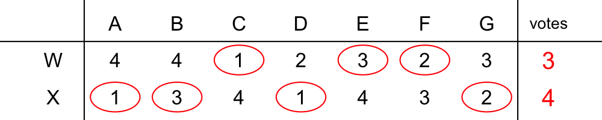

So, X beats W.

Compare candidates W and Y.

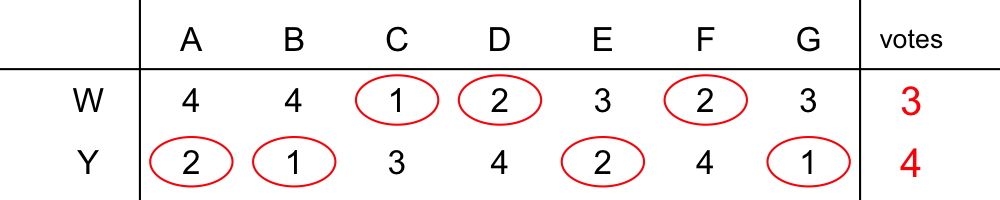

So, Y beats W.

Compare candidates W and Z.

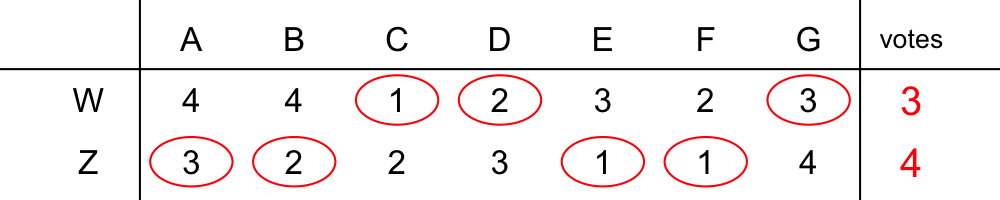

So, Z beats W.

Compare candidates X and Y.

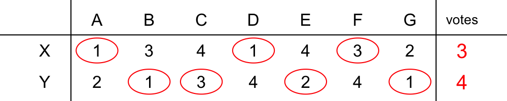

So, Y beats X.

Compare candidates X and Z.

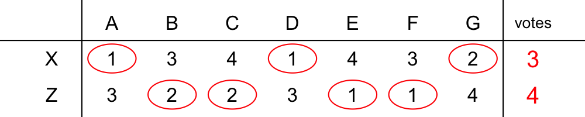

So, Z beats X.

Compare candidates Y and Z.

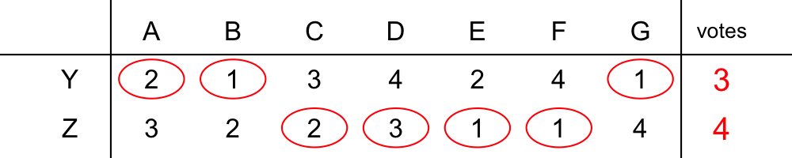

So, Z beats Y.

Notice Z wins against all other candidates. Thus Z is the Condorcet winner.

In Adams, Massachusetts, 4 candidates (W through Z) are running in an election with a single winner. There are 7 voters (A through G) who each rank the candidates from 1 to 4, with 1 meaning first choice and 4 meaning last choice. Those rankings are shown below. Each column represents a single voter's ranking.

|  | A | B | C | D | E | F | G |
| --- | --- | --- | --- | --- | --- | --- | --- |
| candidate W | 2 | 4 | 4 | 2 | 4 | 3 | 1 |
| candidate X | 4 | 1 | 3 | 4 | 3 | 1 | 2 |
| candidate Y | 1 | 2 | 1 | 3 | 2 | 4 | 4 |
| candidate Z | 3 | 3 | 2 | 1 | 1 | 2 | 3 |

A [Condorcet winner](https://en.wikipedia.org/wiki/Condorcet_method) would win in a head-to-head election against any other candidate. Who is the Condorcet winner? (Or, possibly, there is none.)

WXYZNo Condorcet winner!

Consider every head-to-head election. With 4 candidates, there will be ${4\choose 2 }= 6$ pairings (see [combinations](https://en.wikipedia.org/wiki/Binomial_coefficient)).

Compare candidates W and X.

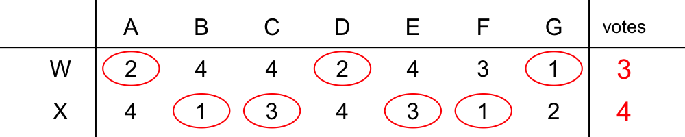

So, X beats W.

Compare candidates W and Y.

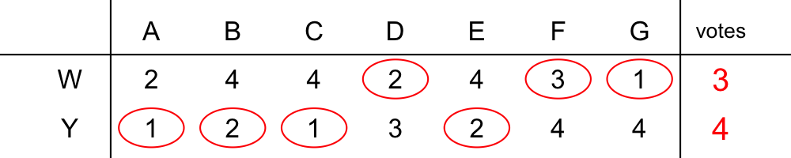

So, Y beats W.

Compare candidates W and Z.

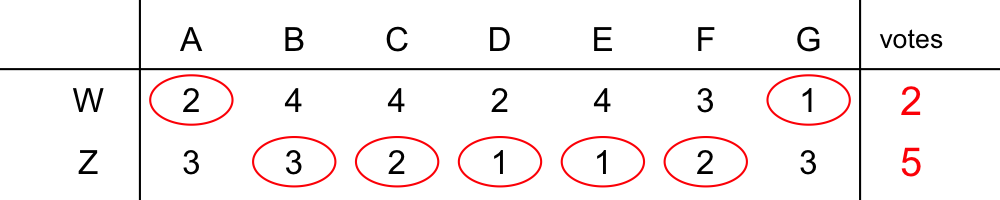

So, Z beats W.

Compare candidates X and Y.

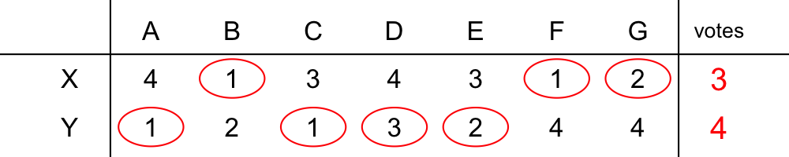

So, Y beats X.

Compare candidates X and Z.

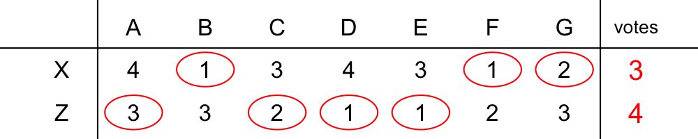

So, Z beats X.

Compare candidates Y and Z.

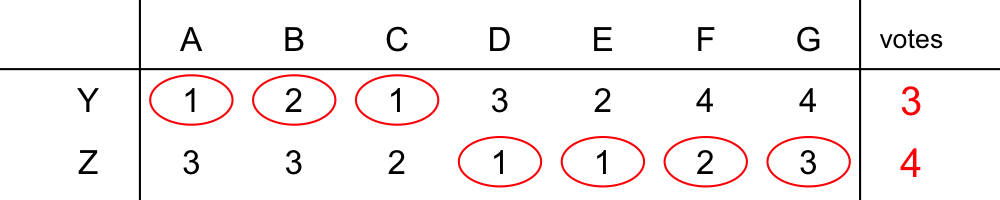

So, Z beats Y.

Notice Z wins against all other candidates. Thus Z is the Condorcet winner.

In Adams, Massachusetts, 4 candidates (W through Z) are running in an election with a single winner. There are 7 voters (A through G) who each rank the candidates from 1 to 4, with 1 meaning first choice and 4 meaning last choice. Those rankings are shown below. Each column represents a single voter's ranking.

|  | A | B | C | D | E | F | G |
| --- | --- | --- | --- | --- | --- | --- | --- |
| candidate W | 1 | 1 | 4 | 3 | 3 | 3 | 3 |
| candidate X | 2 | 3 | 2 | 4 | 1 | 4 | 2 |
| candidate Y | 4 | 2 | 3 | 2 | 2 | 2 | 1 |
| candidate Z | 3 | 4 | 1 | 1 | 4 | 1 | 4 |

A [Condorcet winner](https://en.wikipedia.org/wiki/Condorcet_method) would win in a head-to-head election against any other candidate. Who is the Condorcet winner? (Or, possibly, there is none.)

WXYZNo Condorcet winner!

Consider every head-to-head election. With 4 candidates, there will be ${4\choose 2 }= 6$ pairings (see [combinations](https://en.wikipedia.org/wiki/Binomial_coefficient)).

Compare candidates W and X.

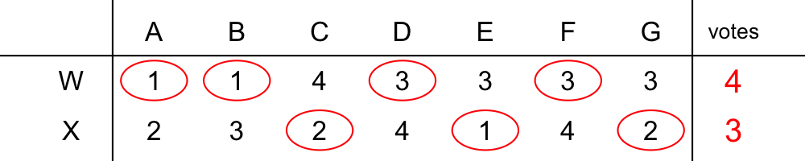

So, W beats X.

Compare candidates W and Y.

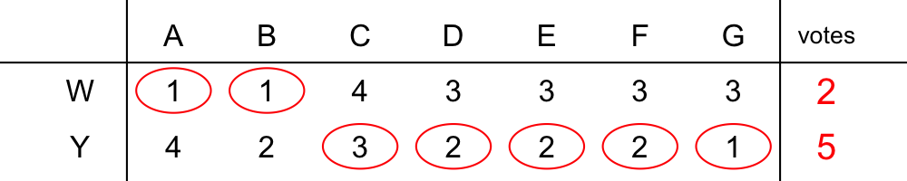

So, Y beats W.

Compare candidates W and Z.

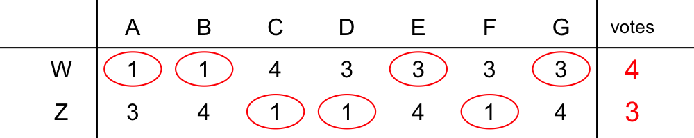

So, W beats Z.

Compare candidates X and Y.

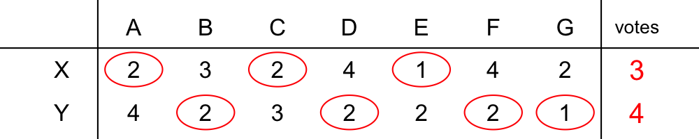

So, Y beats X.

Compare candidates X and Z.

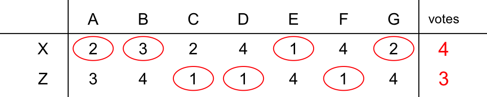

So, X beats Z.

Compare candidates Y and Z.

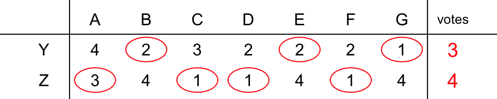

So, Z beats Y.

Organize all this into a winner table.

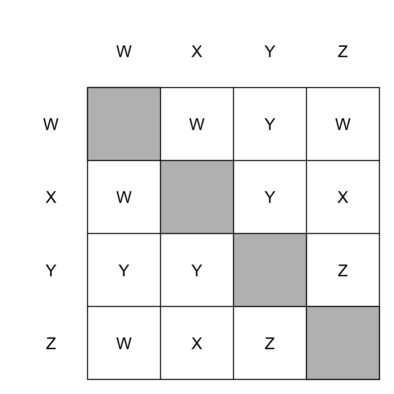

No candidate wins against every other candidate. There is no Condorcet winner.

In Adams, Massachusetts, 4 candidates (W through Z) are running in an election with a single winner. There are 7 voters (A through G) who each rank the candidates from 1 to 4, with 1 meaning first choice and 4 meaning last choice. Those rankings are shown below. Each column represents a single voter's ranking.

|  | A | B | C | D | E | F | G |
| --- | --- | --- | --- | --- | --- | --- | --- |
| candidate W | 3 | 2 | 3 | 3 | 3 | 2 | 4 |
| candidate X | 4 | 3 | 1 | 2 | 1 | 4 | 3 |
| candidate Y | 2 | 1 | 4 | 1 | 2 | 3 | 2 |
| candidate Z | 1 | 4 | 2 | 4 | 4 | 1 | 1 |

A [Condorcet winner](https://en.wikipedia.org/wiki/Condorcet_method) would win in a head-to-head election against any other candidate. Who is the Condorcet winner? (Or, possibly, there is none.)

WXYZNo Condorcet winner!

Consider every head-to-head election. With 4 candidates, there will be ${4\choose 2 }= 6$ pairings (see [combinations](https://en.wikipedia.org/wiki/Binomial_coefficient)).

Compare candidates W and X.

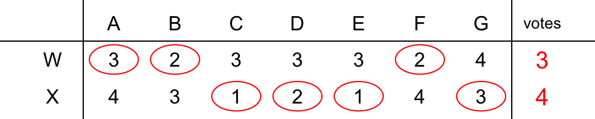

So, X beats W.

Compare candidates W and Y.

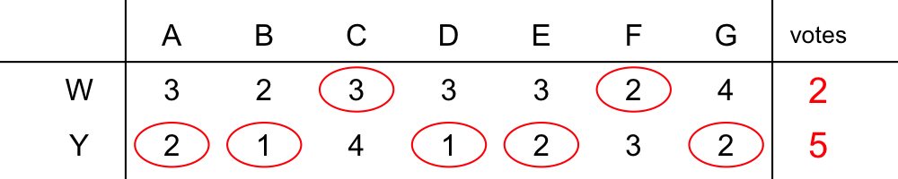

So, Y beats W.

Compare candidates W and Z.

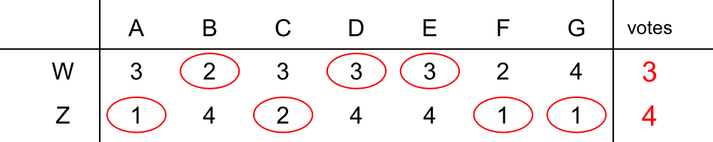

So, Z beats W.

Compare candidates X and Y.

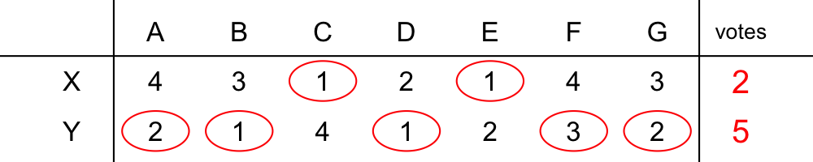

So, Y beats X.

Compare candidates X and Z.

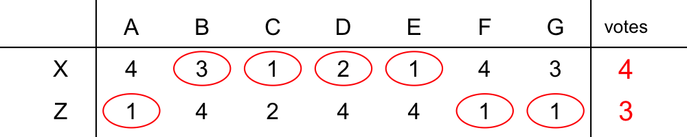

So, X beats Z.

Compare candidates Y and Z.

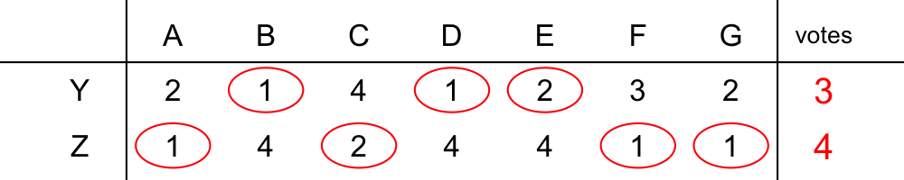

So, Z beats Y.

Organize all this into a winner table.

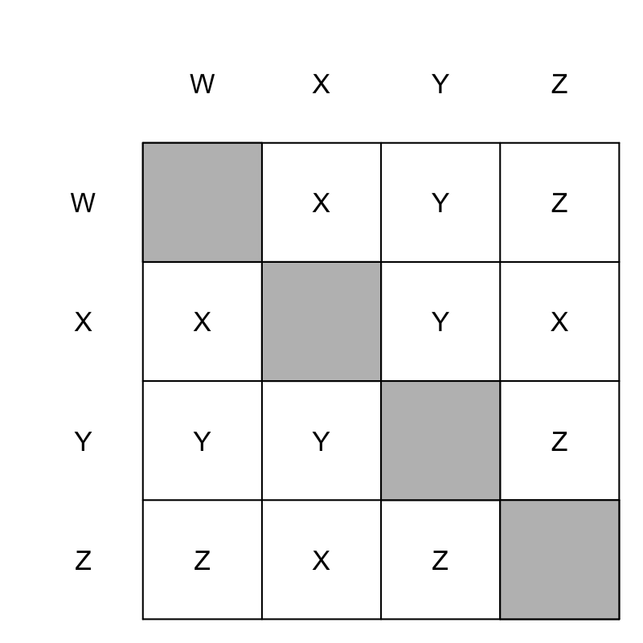

No candidate wins against every other candidate. There is no Condorcet winner.

In Adams, Massachusetts, 4 candidates (W through Z) are running in an election with a single winner. There are 7 voters (A through G) who each rank the candidates from 1 to 4, with 1 meaning first choice and 4 meaning last choice. Those rankings are shown below. Each column represents a single voter's ranking.

|  | A | B | C | D | E | F | G |
| --- | --- | --- | --- | --- | --- | --- | --- |
| candidate W | 2 | 1 | 4 | 2 | 2 | 4 | 2 |
| candidate X | 1 | 2 | 2 | 4 | 4 | 1 | 1 |
| candidate Y | 4 | 4 | 1 | 1 | 1 | 2 | 4 |
| candidate Z | 3 | 3 | 3 | 3 | 3 | 3 | 3 |

A [Condorcet winner](https://en.wikipedia.org/wiki/Condorcet_method) would win in a head-to-head election against any other candidate. Who is the Condorcet winner? (Or, possibly, there is none.)

WXYZNo Condorcet winner!

Consider every head-to-head election. With 4 candidates, there will be ${4\choose 2 }= 6$ pairings (see [combinations](https://en.wikipedia.org/wiki/Binomial_coefficient)).

Compare candidates W and X.

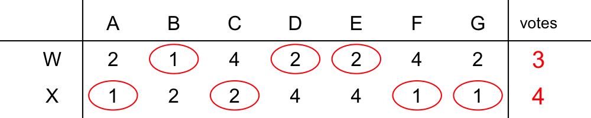

So, X beats W.

Compare candidates W and Y.

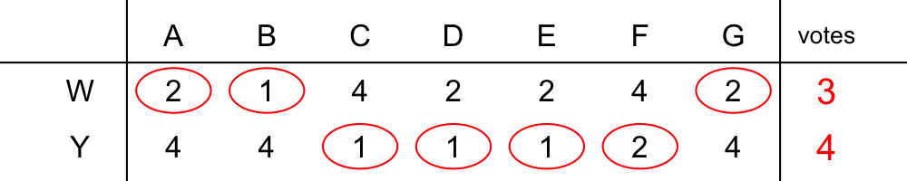

So, Y beats W.

Compare candidates W and Z.

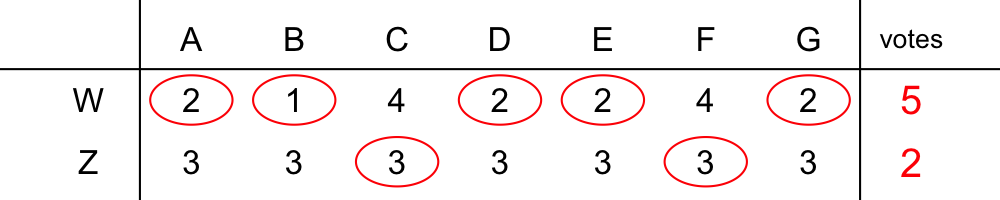

So, W beats Z.

Compare candidates X and Y.

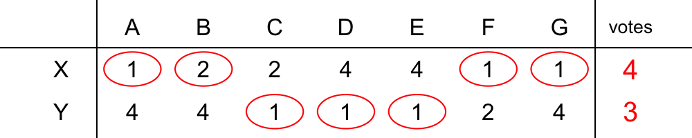

So, X beats Y.

Compare candidates X and Z.

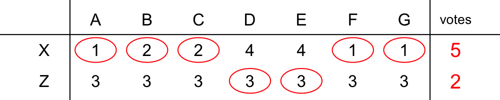

So, X beats Z.

Compare candidates Y and Z.

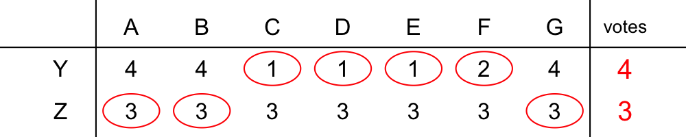

So, Y beats Z.

Organize all this into a winner table.

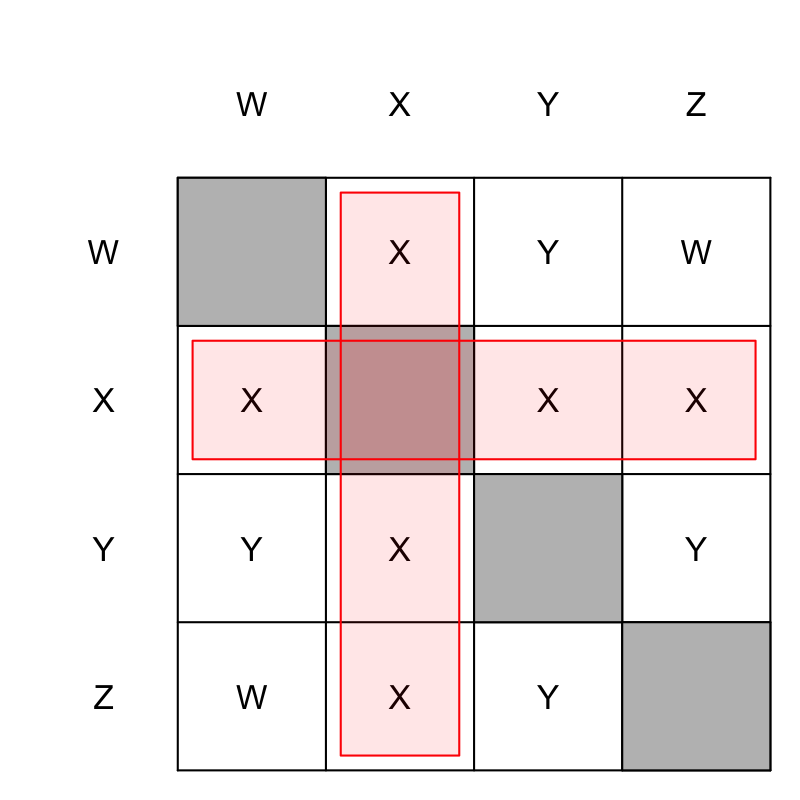

Notice X wins against all other candidates. Thus X is the Condorcet winner.

In Adams, Massachusetts, 4 candidates (W through Z) are running in an election with a single winner. There are 7 voters (A through G) who each rank the candidates from 1 to 4, with 1 meaning first choice and 4 meaning last choice. Those rankings are shown below. Each column represents a single voter's ranking.

|  | A | B | C | D | E | F | G |
| --- | --- | --- | --- | --- | --- | --- | --- |
| candidate W | 1 | 1 | 3 | 4 | 3 | 1 | 2 |
| candidate X | 4 | 3 | 4 | 1 | 4 | 4 | 3 |
| candidate Y | 2 | 2 | 2 | 3 | 1 | 3 | 1 |
| candidate Z | 3 | 4 | 1 | 2 | 2 | 2 | 4 |

A [Condorcet winner](https://en.wikipedia.org/wiki/Condorcet_method) would win in a head-to-head election against any other candidate. Who is the Condorcet winner? (Or, possibly, there is none.)

WXYZNo Condorcet winner!

Consider every head-to-head election. With 4 candidates, there will be ${4\choose 2 }= 6$ pairings (see [combinations](https://en.wikipedia.org/wiki/Binomial_coefficient)).

Compare candidates W and X.

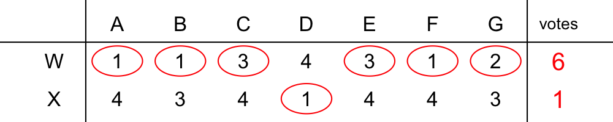

So, W beats X.

Compare candidates W and Y.

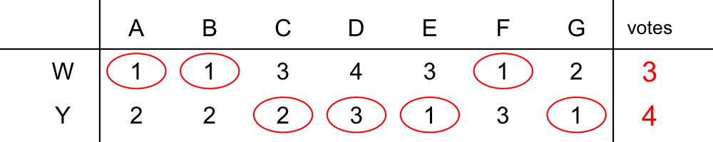

So, Y beats W.

Compare candidates W and Z.

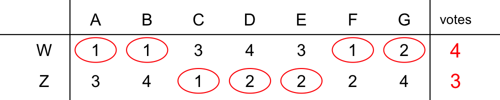

So, W beats Z.

Compare candidates X and Y.

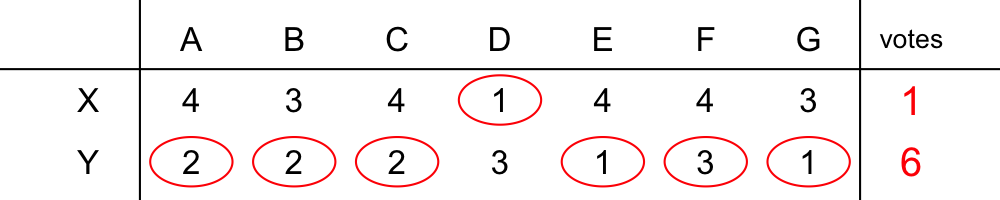

So, Y beats X.

Compare candidates X and Z.

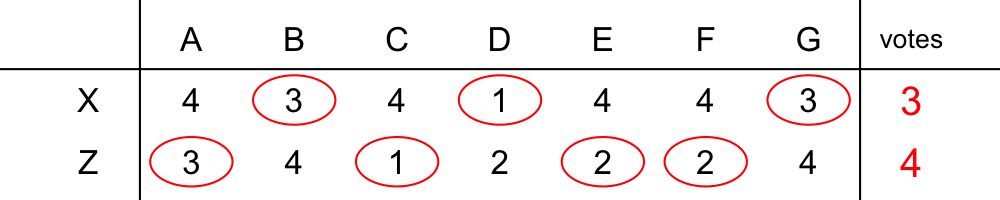

So, Z beats X.

Compare candidates Y and Z.

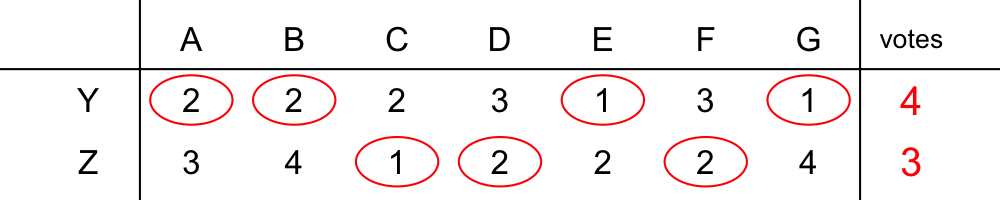

So, Y beats Z.

Organize all this into a winner table.

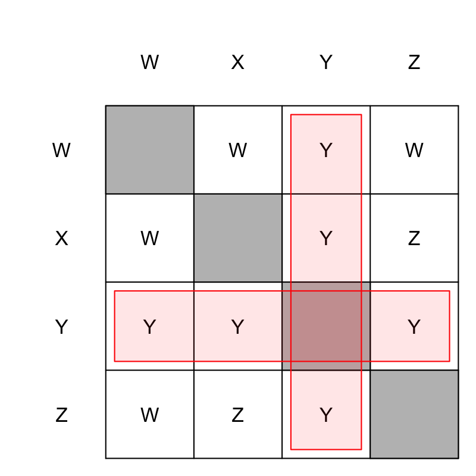

Notice Y wins against all other candidates. Thus Y is the Condorcet winner.

In Adams, Massachusetts, 4 candidates (W through Z) are running in an election with a single winner. There are 7 voters (A through G) who each rank the candidates from 1 to 4, with 1 meaning first choice and 4 meaning last choice. Those rankings are shown below. Each column represents a single voter's ranking.

|  | A | B | C | D | E | F | G |
| --- | --- | --- | --- | --- | --- | --- | --- |
| candidate W | 2 | 3 | 3 | 3 | 3 | 1 | 1 |
| candidate X | 3 | 4 | 2 | 2 | 4 | 2 | 4 |
| candidate Y | 1 | 2 | 4 | 1 | 2 | 4 | 2 |
| candidate Z | 4 | 1 | 1 | 4 | 1 | 3 | 3 |

A [Condorcet winner](https://en.wikipedia.org/wiki/Condorcet_method) would win in a head-to-head election against any other candidate. Who is the Condorcet winner? (Or, possibly, there is none.)

WXYZNo Condorcet winner!

Consider every head-to-head election. With 4 candidates, there will be ${4\choose 2 }= 6$ pairings (see [combinations](https://en.wikipedia.org/wiki/Binomial_coefficient)).

Compare candidates W and X.

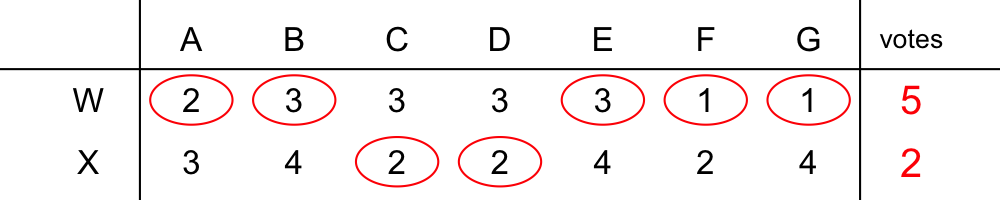

So, W beats X.

Compare candidates W and Y.

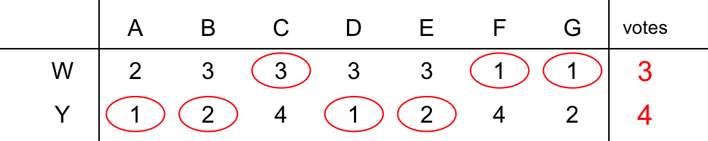

So, Y beats W.

Compare candidates W and Z.

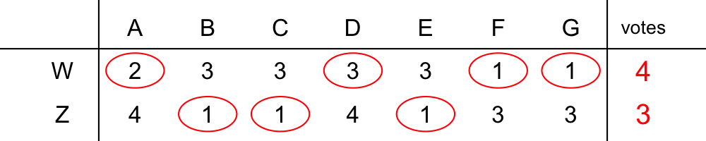

So, W beats Z.